# Homework 2, Data 621

Meaghan Burke

October 14, 2018

### Overview

In this homework assignment, you will work through various classification metrics. You will be asked to create functions in R to carry out the various calculations. You will also investigate some functions in packages that will let you obtain the equivalent results. Finally, you will create graphical output that also can be used to evaluate the output of classification models, such as binary logistic regression.

#### 1. Download the classification output data set (attached in Blackboard to the assignment)

| pregnant | glucose | diastolic | skinfold | insulin | bmi | pedigree | age | class | scored.class | scored.probability |
| --- | --- | --- | --- | --- | --- | --- | --- | --- | --- | --- |
| 7 | 124 | 70 | 33 | 215 | 25.5 | 0.161 | 37 | 0 | 0 | 0.3284523 |
| 2 | 122 | 76 | 27 | 200 | 35.9 | 0.483 | 26 | 0 | 0 | 0.2731904 |
| 3 | 107 | 62 | 13 | 48 | 22.9 | 0.678 | 23 | 1 | 0 | 0.1096604 |
| 1 | 91 | 64 | 24 | 0 | 29.2 | 0.192 | 21 | 0 | 0 | 0.0559984 |
| 4 | 83 | 86 | 19 | 0 | 29.3 | 0.317 | 34 | 0 | 0 | 0.1004907 |
| 1 | 100 | 74 | 12 | 46 | 19.5 | 0.149 | 28 | 0 | 0 | 0.0551546 |

#### 2. The data set has three key columns we will use:

- **class**: the actual class for the observation
- **scored.class**: the predicted class for the observation (based on a threshold of 0.5)
- **scored.probability**: the predicted probability of success for the observation

Use the table() function to get the raw confusion matrix for this scored dataset. Make sure you understand the output. In particular, do the rows represent the actual or predicted class? The columns? *table(Predicted, Observed)*

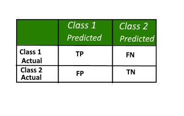

**Confusion Matrix**

|  | 0 | 1 |
| --- | --- | --- |
| 0 | 119 | 30 |
| 1 | 5 | 27 |

#### 3-8. Write a function(s) that takes the data set as a dataframe, with actual and predicted classifications identified, and returns the accuracy, classifications, precision, sensitivity, specificity, f1 score of the predictions.

| accuracy | classification.error.rate | precision | sensitivity | specificity | f1.score |
| --- | --- | --- | --- | --- | --- |
| 0.8066298 | 0.1933702 | 0.7986577 | 0.9596774 | 0.4736842 | 0.8717949 |

#### 9. Before we move on, let’s consider a question that was asked: What are the bounds on the F1 score? Show that the F1 score will always be between 0 and 1.

- By definition, the F1 score is the weighted average of the precision and sensitivty, where an F1 score reaches its best value at *1* and worst at *0*. The F1 score will always be between 0 and 1 because the inputs (precision and sensitivity) are between 0 and 1.

#### 10. Write a function that generates an ROC curve from a data set with a true classification column (class in our example) and a probability column (scored.probability in our example). Your function should return a list that includes the plot of the ROC curve and a vector that contains the calculated area under the curve (AUC). Note that I recommend using a sequence of thresholds ranging from 0 to 1 at 0.01 intervals.

- http://blog.revolutionanalytics.com/2016/08/roc-curves-in-two-lines-of-code.html *helpful ROC source*
- https://www.rdocumentation.org/packages/base/versions/3.5.1/topics/cumsum *cumsum documentation*
- Function inputs:
  - labels: classification.data$class *is the actual classification of each case*
  - scores: classification.data$scored.probability *real-valued prediction scores assigned by some classifier*
- sort by scores (highest to lowest)
- Calculate the sensitivity (TPR- true positive rate) and the specificity (TNR- true negative rate) and the false positive rate (FPR)
- Calculate the aUC manually
- Confirm with the roc() and auc() functions built into the pROC library [problem 13]

Sampling of The ROC Table

| sensitivity | specificity | false.positive.rate | labels |
| --- | --- | --- | --- |
| 0.0175439 | 0.0000000 | 1.0000000 | 1 |
| 0.0175439 | 0.0080645 | 0.9919355 | 0 |
| 0.0350877 | 0.0080645 | 0.9919355 | 1 |
| 0.0526316 | 0.0080645 | 0.9919355 | 1 |
| 0.0701754 | 0.0080645 | 0.9919355 | 1 |
| 0.0877193 | 0.0080645 | 0.9919355 | 1 |
| 0.1052632 | 0.0080645 | 0.9919355 | 1 |
| 0.1228070 | 0.0080645 | 0.9919355 | 1 |
| 0.1403509 | 0.0080645 | 0.9919355 | 1 |
| 0.1578947 | 0.0080645 | 0.9919355 | 1 |

Manually Calculated AUC

| x |
| --- |
| -0.8503 |

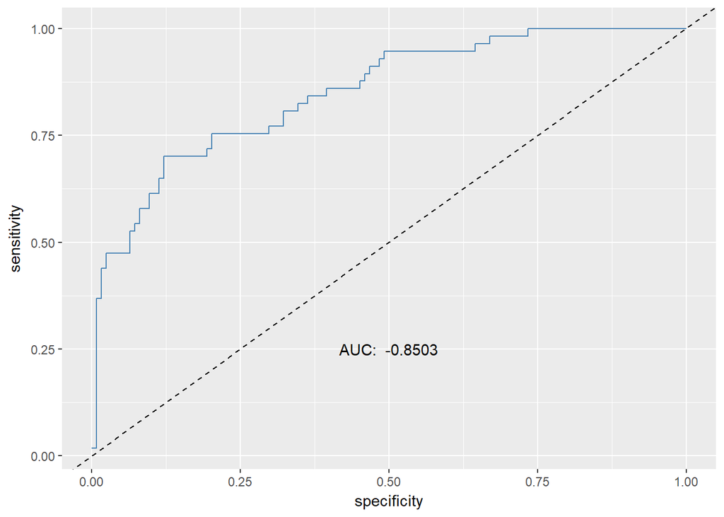

#### 11. Use your created R functions and the provided classification output data set to produce all of the classification metrics discussed above.

| accuracy | classification.error.rate | precision | sensitivity | specificity | f1.score |
| --- | --- | --- | --- | --- | --- |
| 0.8066298 | 0.1933702 | 0.7986577 | 0.9596774 | 0.4736842 | 0.8717949 |

#### 12. Investigate the caret package. In particular, consider the functions confusionMatrix, sensitivity, and specificity. Apply the functions to the data set. How do the results compare with your own functions?

- The output of the caret function appears to be the same as the manually calculated values

```
## Confusion Matrix and Statistics
##
##
##       0   1
##   0 119  30
##   1   5  27
##
##                Accuracy : 0.8066
##                  95% CI : (0.7415, 0.8615)
##     No Information Rate : 0.6851
##     P-Value [Acc > NIR] : 0.0001712
##
##                   Kappa : 0.4916
##  Mcnemar's Test P-Value : 4.976e-05
##
##             Sensitivity : 0.9597
##             Specificity : 0.4737
##          Pos Pred Value : 0.7987
##          Neg Pred Value : 0.8438
##              Prevalence : 0.6851
##          Detection Rate : 0.6575
##    Detection Prevalence : 0.8232
##       Balanced Accuracy : 0.7167
##
##        'Positive' Class : 0
##
```

|  | mb.calcs | caret.cals |
| --- | --- | --- |
| accuracy | 0.8066298 | 0.8066298 |
| classification.error.rate | 0.1933702 | 0.1933702 |
| precision | 0.7986577 | 0.7986577 |
| sensitivity | 0.9596774 | 0.9596774 |
| specificity | 0.4736842 | 0.4736842 |
| f1.score | 0.8717949 | 0.8717949 |

#### 13. Investigate the pROC package. Use it to generate an ROC curve for the data set. How do the results compare with your own functions?

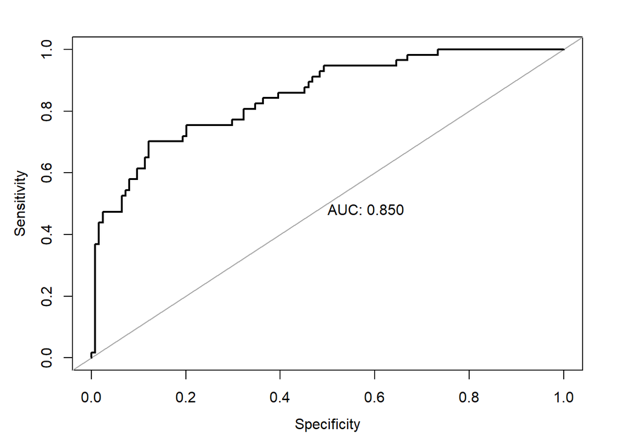